# Car Make Classifier

In the modern automotive industry, visual brand identity plays a crucial role. Each car manufacturer designs vehicles with unique styling elements—from grille shape to headlight design—that make their cars instantly recognizable.

In this project, we aim to harness the power of image classification using deep learning to build a model that can automatically identify whether a car in an image belongs to BMW, Audi or Mercedes.

### 🎯 Objective

For the initial model we are going to feed it with images from different website listings, but also images from traffic cameras in order to tackle potential challenges if a blurry image is sent to the model.

The goal is to develop a machine learning model that takes a full image of a car and correctly classifies it as one of the brands from above. The model will be trained on a curated image dataset and evaluated on its ability to generalize to new, unseen car images.

### Project Approach Idea

For this project, we will use a **hybrid approach** that leverages the strengths of both deep learning and classical machine learning:

1. **Feature Extraction with CNN (TensorFlow/MobileNetV2):**
   - We use a pre-trained convolutional neural network (CNN), specifically MobileNetV2, to process each car image.
   - The CNN is not trained from scratch; instead, we use its learned filters to extract high-level, abstract features from the images.
   - The output for each image is a compact feature vector (not a class prediction), which captures important visual patterns.
2. **Classification with SVC (Support Vector Classifier):**
   - The feature vectors extracted by the CNN are used as input to a Support Vector Classifier (SVC), a classical machine learning algorithm.
   - The SVC learns to separate the feature vectors into different car brands (Audi, BMW, Mercedes) based on the patterns learned by the CNN.

**Why this combination?**

- CNNs are excellent at extracting meaningful features from images, even with limited data, when using pre-trained models.
- SVCs are effective at finding decision boundaries in lower-dimensional feature spaces, especially with small to medium-sized datasets.
- This hybrid approach allows us to benefit from deep learning's representational power without needing a huge labeled dataset or extensive training time.

**Workflow Recap:**

1. Images → MobileNetV2 (CNN) → Feature Vectors
2. Feature Vectors → SVC → Brand Prediction

This method is often called "transfer learning with classical classifier" and is widely used when data is limited but high-quality pre-trained models are available.

## 🌐 Domain Context

In today's digital landscape, apps that leverage computer vision are becoming increasingly prevalent across industries — from retail and security to automotive technology. Within the automotive domain, identifying the make of a vehicle from a photo has practical value in multiple applications: car listing platforms, mobile parking apps, AI-powered insurance inspections, and even driver-assistance systems.

Ultimately, this project demonstrates how AI can bridge the gap between real-world visual data and intelligent brand recognition, opening the door for smarter, image-driven applications in the automotive and consumer tech space.

```python
import copy, pathlib, math
import PIL.Image as Image

import sklearn
import numpy
import matplotlib
import matplotlib.pyplot as plt

print("scikit-learn version:", sklearn.__version__)     # 1.2.2
print("numpy version:", numpy.__version__)              # 2.1.3
print("matplotlib version:", matplotlib.__version__)    # 3.10.2
```

```
scikit-learn version: 1.7.0
numpy version: 2.1.3
matplotlib version: 3.10.3
```

## 📦 Data Provisioning

For this project, the dataset was curated from various sources on the internet. Images representing three car brands—**Audi**, **BMW**, and **Mercedes**—were collected. The dataset includes a mix of clear, high-quality images typically used for car listings, as well as blurrier images captured from traffic cameras to ensure diversity and robustness in the model.

- **Brands:** Audi, BMW, Mercedes
- **Image Count:** At least 50 images per brand, with some brands having more
- **Image Variety:** Both clear/listing images and real-world, lower-quality images

All images are organized in subfolders named after their respective brands. This structure allows for straightforward loading and labeling during the data preparation phase.

```python
import os
from PIL import Image, UnidentifiedImageError


input_root = "car_dataset"
output_size = (224, 224) #Because the MobilNetV2 expects images of size 224x224
accepted_formats = ('.jpg', '.jpeg', '.png')


for brand in os.listdir(input_root):
    brand_path = os.path.join(input_root, brand)
    if not os.path.isdir(brand_path): # Check if the path is a directory
        continue

    print(f"Processing: {brand}")
    # count = 1 Count for renaming the file names | After done ones we will commnet it out not to cause confusion

    for filename in os.listdir(brand_path):
        file_path = os.path.join(brand_path, filename)

       # Checking if the file is an image based on its extension
        if not filename.lower().endswith(accepted_formats):
            print(f"Skipping non-image: {filename}")
            continue

        try:
            with Image.open(file_path) as img:
                img = img.convert("RGB") # Converting to RGB in case of PNG or other formats
                img = img.resize(output_size) # Resizing the images to 224x224

                # new_filename = f"{brand.lower()}_{count:03}.jpg" changing the name of the folder | After done ones we will commnet it out not to cause confusion
                # new_path = os.path.join(brand_path, filename) | After done ones we will commnet it out not to cause confusion
                img.save(file_path, "JPEG")

                #if filename != f:
                 #   os.remove(file_path)

                #count += 1 | After done ones we will commnet it out not to cause confusion

        except (UnidentifiedImageError, OSError) as e: #In case of corrupted images
            print(f"Removing corrupted file: {filename}")
            os.remove(file_path)
```

```
Processing: audi
Skipping non-image: blurry
Processing: bmw
Skipping non-image: blurry
Processing: mercedes
Skipping non-image: blurry
```

```python
for brand in os.listdir("car_dataset"):
    print(f"{brand} has {len(os.listdir(os.path.join(input_root, brand)))} images.")
```

```
audi has 67 images.
bmw has 59 images.
mercedes has 56 images.
```

# 📃 Sample the data

To get an impression of the data, here a sample from the loaded images is plotted so see if they we loaded correctly.

[figure not shown]

```python
import random

classes = ["bmw", "audi", "mercedes"]
images_per_class = 5

fig, axes = plt.subplots(len(classes), images_per_class, figsize=(images_per_class * 2.5, len(classes) * 2.5))
fig.suptitle("Sample Images per Class", fontsize=16)

# Ensure the axes are iterable even if there's only one class
for row, cls in enumerate(classes):
    # Get the directory for the class
    class_dir = os.path.join(input_root, cls)
    images = [f for f in os.listdir(class_dir) if f.lower().endswith(".jpg")] # Get all images in the class directory
    sampled = random.sample(images, min(images_per_class, len(images))) # Sample images from the class directory

    for col, img_file in enumerate(sampled): # Iterate through sampled images
        img_path = os.path.join(class_dir, img_file)
        img = Image.open(img_path).resize(output_size)

        ax = axes[row][col] if len(classes) > 1 else axes[col]
        ax.imshow(img)
        ax.axis("off")
        if col == 0:
            ax.set_title(cls.capitalize(), fontsize=12)

plt.tight_layout()
plt.subplots_adjust(top=0.88)
plt.show()
```

## 🧠 Execution of Idea

In this section, we will begin our hybrid approach for modeling and firstly we will leverage TensorFlow, a powerful open-source deep learning framework, to extract high-level features from our car images using a pre-trained convolutional neural network (CNN). TensorFlow is widely used for building and training neural networks due to its flexibility, scalability, and strong support for GPU acceleration.

Instead of training a deep neural network from scratch (which requires a large dataset and significant computational resources), we use a pre-trained model (MobileNetV2) as a feature extractor. This model has already learned to recognize a wide variety of visual patterns from millions of images. By passing our car images through MobileNetV2 (excluding its final classification layer), we obtain compact and informative feature vectors that represent each image.

These feature vectors are then going to be used as input to our SVC algo. This hybrid approach combines the representational power of deep learning (for feature extraction) with the simplicity and effectiveness of SVC (for classification), making it well-suited for our relatively small dataset.

```python
import os
import numpy as np
from tensorflow.keras.preprocessing.image import load_img, img_to_array
from tensorflow.keras.applications.mobilenet_v2 import preprocess_input
from tqdm import tqdm

image_size = (224, 224)
dataset_path = "car_dataset"

X = [] # List to hold image data
y = [] # List to hold corresponding labels
class_labels = {"audi": 0, "bmw": 1, "mercedes": 2} # Initialize class labels with corresponding indices

for label in class_labels:
    folder = os.path.join(dataset_path, label)
    for img_name in tqdm(os.listdir(folder), desc=f"Loading {label}"): # Iterate through each class folder
        try:
            img_path = os.path.join(folder, img_name) # Full path to the image
            img = load_img(img_path, target_size=image_size)
            img_array = img_to_array(img)
            img_array = preprocess_input(img_array) # Preprocess the image for MobileNetV2
            X.append(img_array)
            y.append(class_labels[label]) # Append the corresponding label
        except Exception as e:
            print(f"Skipped {img_name}: {e}")
```

```
Skipped blurry: [Errno 13] Permission denied: 'car_dataset\\audi\\blurry'
```

```
Skipped blurry: [Errno 13] Permission denied: 'car_dataset\\bmw\\blurry'
```

```
Skipped blurry: [Errno 13] Permission denied: 'car_dataset\\mercedes\\blurry'
```

Next, we convert the lists of image arrays (`X`) and labels (`y`) into NumPy arrays, which are required for efficient processing with deep learning models. We then load the pre-trained MobileNetV2 model from Keras, excluding its top classification layer and using global average pooling. This model is used to extract high-level feature vectors from each image in our dataset. By passing our images through MobileNetV2, we obtain a compact representation (`features`) for each image, which will be used as input for our machine learning classifier.

```python
X = np.array(X)
y = np.array(y)

from tensorflow.keras.applications import MobileNetV2

mobilenet = MobileNetV2(include_top=False, weights='imagenet', input_shape=(224, 224, 3), pooling='avg') # Load the MobileNetV2 model without the top layer and with average pooling
features = mobilenet.predict(X, verbose=1) # Extract features from the images using MobileNetV2
```

```
6/6 ━━━━━━━━━━━━━━━━━━━━ 3s 412ms/step
```

Now that we got our features let's now use them for our SVC algorithm!

```python
from sklearn.model_selection import train_test_split
from sklearn.svm import SVC
from sklearn.metrics import classification_report, confusion_matrix

X_train, X_test, y_train, y_test = train_test_split(features, y, test_size=0.2, random_state=42, stratify=y)

clf = SVC(C=1.0, kernel='rbf', probability=True)
clf.fit(X_train, y_train)
score = clf.score(X_test, y_test)

y_pred = clf.predict(X_test)
print(classification_report(y_test, y_pred, target_names=class_labels.keys()))
print("Model accuracy:", score)
```

```
              precision    recall  f1-score   support

        audi       0.45      0.69      0.55        13
         bmw       0.62      0.42      0.50        12
    mercedes       0.50      0.36      0.42        11

    accuracy                           0.50        36
   macro avg       0.53      0.49      0.49        36
weighted avg       0.52      0.50      0.49        36

Model accuracy: 0.5
```

We achieved an accuracy of 0.50, which considering tha small dataset is decent. Now the biggest problem we immediatelly can see is with *mercedes*: Struggling at 0.36 recall. One main reason is probably the fact that out of the three car brands Audi has the most images and here we clearly see that **the more images we add to each car brand, the better the score we get from the report.**

Let's now visualize some samples from the predictions of the model.

```
Clipping input data to the valid range for imshow with RGB data ([0..1] for floats or [0..255] for integers). Got range [-1.0..1.0].
```

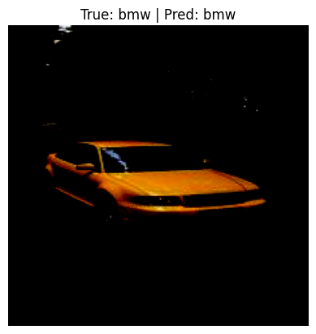

```
Clipping input data to the valid range for imshow with RGB data ([0..1] for floats or [0..255] for integers). Got range [-1.0..1.0].
```

[figure not shown]

```
Clipping input data to the valid range for imshow with RGB data ([0..1] for floats or [0..255] for integers). Got range [-1.0..1.0].
```

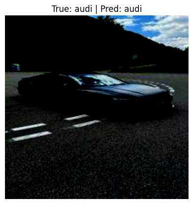

```
Clipping input data to the valid range for imshow with RGB data ([0..1] for floats or [0..255] for integers). Got range [-1.0..1.0].
```

[figure not shown]

```
Clipping input data to the valid range for imshow with RGB data ([0..1] for floats or [0..255] for integers). Got range [-1.0..1.0].
```

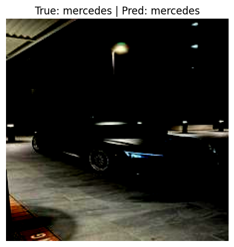

```
Clipping input data to the valid range for imshow with RGB data ([0..1] for floats or [0..255] for integers). Got range [-1.0..1.0].
```

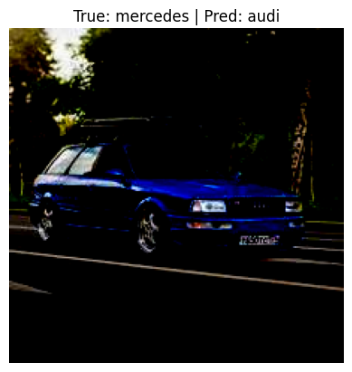

```
Clipping input data to the valid range for imshow with RGB data ([0..1] for floats or [0..255] for integers). Got range [-1.0..1.0].
```

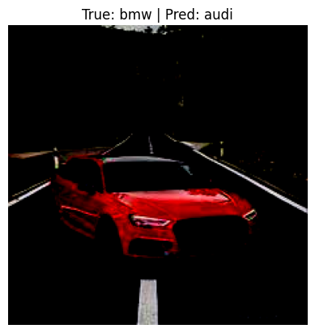

```
Clipping input data to the valid range for imshow with RGB data ([0..1] for floats or [0..255] for integers). Got range [-1.0..1.0].
```

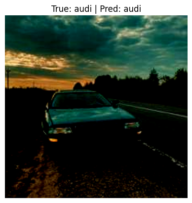

```
Clipping input data to the valid range for imshow with RGB data ([0..1] for floats or [0..255] for integers). Got range [-1.0..0.94509804].
```

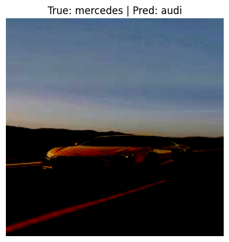

```
Clipping input data to the valid range for imshow with RGB data ([0..1] for floats or [0..255] for integers). Got range [-1.0..1.0].
```

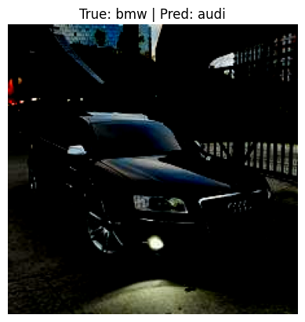

```python
import matplotlib.pyplot as plt

inv_class_labels = {v: k for k, v in class_labels.items()}

for i in range(10):
    idx = np.random.randint(0, len(y_test))
    true_label = inv_class_labels[y_test[idx]]
    pred_label = inv_class_labels[y_pred[idx]]

    plt.imshow(X[idx])
    plt.title(f"True: {true_label} | Pred: {pred_label}")
    plt.axis('off')
    plt.show()
```

Now a common to further improve our SVM classifier's performance, we will perform hyperparameter tuning using `GridSearchCV`. Grid search is a widely used and systematic approach for finding the optimal combination of hyperparameters for a machine learning model. By exhaustively searching over a specified parameter grid, `GridSearchCV` evaluates model performance for each combination using cross-validation, helping to identify the settings that yield the best results.

This method is common practice in machine learning because model performance can be highly sensitive to hyperparameter choices such as the regularization strength (`C`), kernel type, and kernel-specific parameters (like `gamma`). By automating the search process and using cross-validation, we reduce the risk of overfitting to a particular train-test split and increase the likelihood of finding a more robust model configuration.

In the next step, we will use `GridSearchCV` to tune the SVM's `C`, `kernel`, and `gamma` parameters, aiming to maximize classification accuracy on our car brand dataset.

```python
from sklearn.model_selection import GridSearchCV

param_grid = {
    'C': [0.1, 1, 5, 10],
    'kernel': ['linear', 'rbf', 'poly'],
    'gamma': ['scale', 'auto']
}

grid = GridSearchCV(SVC(probability=True), param_grid, cv=3, n_jobs=-1)
grid.fit(X_train, y_train)
grid_score = grid.score(X_test, y_test)
print("Best score from grid search:", grid_score)

print("Best params:", grid.best_params_)
y_pred = grid.predict(X_test)
print(classification_report(y_test, y_pred, target_names=class_labels.keys()))
```

```
Best score from grid search: 0.4166666666666667
Best params: {'C': 0.1, 'gamma': 'scale', 'kernel': 'linear'}
              precision    recall  f1-score   support

        audi       0.31      0.38      0.34        13
         bmw       0.53      0.67      0.59        12
    mercedes       0.40      0.18      0.25        11

    accuracy                           0.42        36
   macro avg       0.42      0.41      0.40        36
weighted avg       0.41      0.42      0.40        36
```

That may be the only possibility because regarding SVM — we may have hit the limit of what a fixed-feature SVM model can do without additional data or a more flexible learner.

Now that we have tried hyperparameter tuning with GridSearchCV, we observed that the accuracy did not improve and even dropped. To further assess the robustness and generalization ability of our model, we will perform cross-validation.

**Why do cross-validation you may ask.** We do that to:

- Obtain a more reliable estimate of model performance by reducing the impact of a particular train-test split.
- Detect overfitting or underfitting, as consistent performance across folds indicates a stable model.
- Make better use of limited data, since every sample is used for both training and validation.

```python
from sklearn.model_selection import cross_val_score

# Perform 5-fold cross-validation on the SVC using the extracted features
cv_scores = cross_val_score(clf, features, y, cv=5, scoring='accuracy')
print("Cross-validation scores:", cv_scores)
print("Mean CV accuracy:", np.mean(cv_scores))
```

```
Cross-validation scores: [0.44444444 0.38888889 0.41666667 0.41666667 0.31428571]
Mean CV accuracy: 0.3961904761904762
```

#### Feedback

Now a interesting feedback was given to us. As our cross validation proved there is some noise in our dataset and our consultant for EDA suggested to try out if the model performs better with only the images that are not blurry (the ones, which can be used for car listings in a website). So let's try this by just making a new directory in our car_dataset and call it "blurry", where we will manually move the car images, which are coming from the traffic cameras to this directory.

Additionally we will change the name of those images in order for future improvements to easily then find those exact images. Now in order to follow a nice flow for our notebook, let's not repeat any code and we are going to provide snapshots of the results we got.

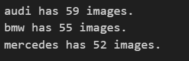

Firstly the dataset stayed consistent and only a few images were removed from the dataset:

- Audi: 8 images removed
- BMW: 4 images removed
- Mercedes: 4 images removed

So total images for each car brand remained above our goal - 50 images. Now we need to note that there are still some traffic images left in the dataset, but because they are still relatively readable even for the normal human eye I decided to keep them in order not to remove most of the images for each car brand.

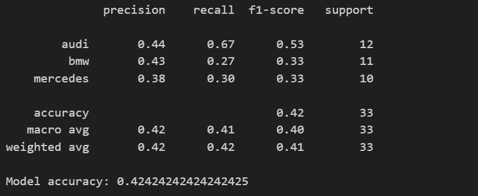

After cleaning the dataset by removing blurry or low-quality traffic camera images, we noticed a drop in overall accuracy from 0.50 to 0.42. While this might seem counterintuitive at first, there are several important factors contributing to this outcome:

- Reduced Data Volume: By removing blurry images, the dataset became smaller. Deep learning models (even fine-tuned ones like MobileNetV2) typically perform better with more data. Fewer samples may lead to overfitting or poor generalization.
- Overfitting Risk Increased: Cleaner data can paradoxically cause the model to latch onto features that don't generalize well, especially when training data is limited.
- Loss of Variance in Input: While blurry images may appear unhelpful, they do contribute to diversity. Removing them may result in the model seeing more uniform samples, potentially limiting its robustness.

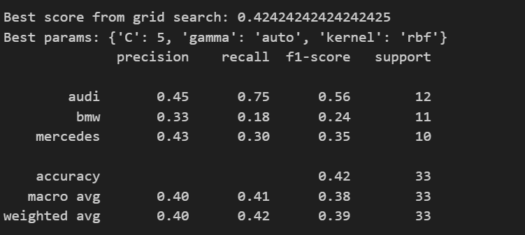

After removing blurry and traffic-style images, we re-ran a GridSearchCV to fine-tune the SVM classifier. The best parameters selected were: {'C': 5, 'gamma': 'auto', 'kernel': 'rbf'}

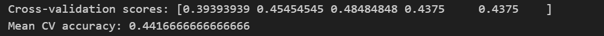

The new cross-validation scores across 5 folds show a clear improvement after removing blurry and irrelevant images:

After cleanup: Mean accuracy increased to ~44.17%, and all folds stayed consistently above 39%, peaking at nearly 48.5%.

This suggests that cleaning the dataset helped reduce noise, leading to more stable and improved generalization across different validation splits. Even with a small dataset, removing low-quality images positively impacted consistency and overall model reliability.

## ✅ Conclusion and Next Steps

Although the model’s final accuracy (~42–44%) is modest, it shows consistent improvements through:

## 🔍 Key Takeaways:

Data quality significantly affects performance—even minor cleaning steps helped.

## 🧠 Future Improvements:

To further boost performance, here’s what should be done next:

- Increase dataset size per class (at least 200–500 images per car brand).
- Augment training images (flips, rotations, lighting adjustments) to improve generalization.
- Could add a “Could Not Detect” category for ambiguous or misclassified cases.
- Balance class distribution or use weighted loss functions.
- Filter out colors or backgrounds that mislead the model (sky, yellow/blue shades).

## Overall:

With more time and resources, this project can evolve into a robust and scalable vehicle classification system. Even with just two weeks, the iterative improvements show promise and highlight how much impact clean data and tuning can have.